# Denver City Council: local ideal points, 2023–2026

Current-term roll calls, 2023–2026 · Preliminary analysis

Author

Boris Shor

Updated

October 8, 2026

This pilot places 13 Denver councilmembers on a common voting spectrum. Lewis and Parady occupy the progressive end, while Hinds sits at the opposite endpoint. His placement is heavily influenced by repeated records of a contract-oversight dispute, not evidence that he is Denver’s most conservative member. The source investigation below explains that distinction. District presidential voting has only a weak relationship with the fitted positions.

**13 members**  
Pooled current-term roster

**11 districts**  
Plus two at-large seats

**300 voting items**  
Includes repeated agenda records

**3,640 votes**  
Recorded yeas and nays

## Dataset

The roll calls come from the *MyTown* corpus of local-government meetings and votes (Jacob Greene, 2026, CC BY 4.0, [DOI 10.57967/hf/9676](https://doi.org/10.57967/hf/9676)), downloaded September 14, 2026. Preserved local extracts, rather than later downloads, define this analysis.

### Coverage and construction

The source extract contains **96,899 Denver City Council member-vote records**, **152 meetings**, and **7,869 reconstructed vote events** from July 17, 2023 through August 31, 2026. It covers the 13 people on the term’s elected roster: eleven district representatives and two at-large members. Denver’s official [council directory](https://www.denvergov.org/Government/Agencies-Departments-Offices/Agencies-Departments-Offices-Directory/Denver-City-Council/Council-Members-Websites-Info) supplies the district assignments. Sarah Parady resigned on August 5, 2026, so this is a pooled roster over the period rather than a claim that all 13 held office on the final date.

| Measure | Value |
| --- | --- |
| Member-vote records | 96,899 |
| Council meetings | 152 |
| Coverage | July 17, 2023–August 31, 2026 |
| Reconstructed vote events | 7,869 |
| Events with yea and nay | 301 |
| Events with at least two members on each side | 151 |
| Events retained for the main fit | 300 |
| Council members | 13 |

Denver’s flattened data sometimes give several distinct roll-call events in one meeting the same generic motion text. The analysis separates those events by their order within each member’s preserved source records. Eighteen meeting–motion groups have inconsistent repetition counts across members and are excluded rather than aligned by guesswork. This is the principal Denver-specific construction decision.

Yea is coded 1 and nay 0; absence, abstention, and unobserved entries are missing. The analysis excludes members with fewer than four usable votes, unanimous items, and one unusually sparse item with fewer than ten observed yea/nay votes. A single dissenter is enough to retain an item in this thirteen-member council. This leaves **300 contested voting items**, containing 3,640 usable votes, including 150 one-member-minority items. These are recorded items, not necessarily independent decisions: the Hinds investigation below identifies a large repeated block vote.

## Results

### Council ideal points

An **ideal point** is a one-dimensional summary of voting similarity. Members placed near one another tend to take the same side on contested roll calls; members far apart tend to oppose one another. The units and direction are relative to this Denver sample, so the estimates are not directly comparable to the numerical Chicago scores and should not be treated as absolute liberal–conservative ratings.

The estimates come from a Bayesian roll-call model.

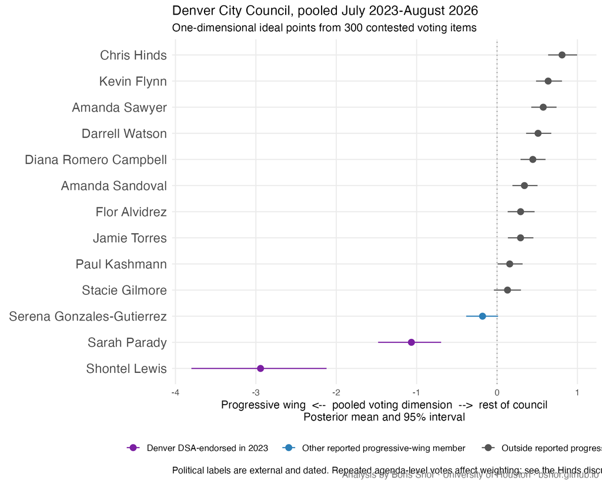

Pooled Denver ideal points. Purple identifies the two successful 2023 Denver DSA-endorsed candidates; blue identifies the other member of the three-person progressive wing reported by Axios.

### Individual members and policy controversies

The clearest feature is the distance between **Lewis** (-2.94) and **Parady** (-1.07) and most of the rest of the council. **Gonzales-Gutierrez** (-0.18) falls in between but remains the next-lowest member. Independent reporting identifies these same three as the council’s progressive wing, associated with social housing, collective bargaining for city workers, renter interests, and expanded substance-use treatment. Denver DSA endorsed Lewis and Parady in the 2023 election; Lewis publicly describes herself as a democratic socialist. [Axios on the progressive wing](https://www.axios.com/local/denver/2025/01/02/city-councils-progressives-top-priorities-2025); [Denver DSA on Lewis](https://pikapress.denverdsa.org/denver-dsa-endorses-shontel-m-lewis-for-mayor-of-denver/)

**Flynn** (0.64) and **Sawyer** (0.57) oppose the progressive trio on several salient issues, although neither occupies the fitted endpoint. In January 2025, Lewis, Parady, and Gonzales-Gutierrez voted to loosen Denver’s cap and distance restrictions on syringe-access programs, while Flynn and Sawyer voted no. Supporters framed the ordinance as harm reduction amid rising overdose deaths; opponents objected to removing the program cap and the 1,000-foot buffer around schools and day-care centers. The council passed it 8–5, but Mayor Mike Johnston vetoed it. [Denverite on the vote](https://denverite.com/2025/01/13/denver-city-council-more-needle-exchange-sites/); [Axios on the veto](https://www.axios.com/local/denver/2025/01/15/mayor-denver-veto-expanding-needle-exchange)

These members also divided over Denver’s 2025 repeal of minimum off-street parking requirements. Parady argued that the change could reduce car dependence, while Flynn said it would not lower housing costs and Sawyer favored parking maximums and better transit instead. The broader controversy was whether mandatory parking raises construction costs and suppresses housing supply, or whether eliminating it simply shifts parking pressure onto neighborhoods in a city where many residents still rely on cars. [Axios on the parking repeal](https://www.axios.com/local/denver/2025/08/05/denver-parking-requirements-developers-builders)

The roll-call dimension is not simply support for or opposition to the mayor. Members form different coalitions across budgets, land use, public safety, and individual projects. The progressive endpoint has independent substantive support, but Hinds’s position is particularly sensitive to repeated agenda-level records.

### Why Hinds has so many lone nays

Hinds is the sole nay in **57 retained item records**, but they cover just **four source-level votes at three meetings**. Fifty-two records repeat one December 1, 2025 block vote on transportation and infrastructure contracts; another two repeat the separately considered HDR Engineering contract. The April 14 sidewalk contract is also represented twice. The remaining vote, August 26, 2024, concerns an advisory-board appointment. The official minutes confirm the distinction between agenda items and actual voting events. [December minutes](https://denver.legistar.com/View.ashx?GUID=A70D059A-AA3B-43AC-8318-C8F82C21C92F&ID=15017253&M=F)

His substantive objection on December 1 was **council oversight**: advance authorization of roughly $600 million in on-call contracts would let the department commission later work without returning for individual council approval. He recognized the efficiency argument but objected to the loss of subsequent votes. [Colorado Politics](https://www.coloradopolitics.com/2025/12/01/denver-city-council-approves-600-million-for-doti-on-call-services/)

On April 14, he opposed a $15 million, three-year sidewalk-program contract because its deliverables and deadlines were insufficiently specific. He proposed a $5 million, one-year alternative—not abandoning sidewalks. The recorded vote was 11–1, with Parady absent. [Colorado Politics](https://www.coloradopolitics.com/2025/04/14/council-gives-nod-to-15-million-deal-to-launch-citys-sidewalk-program-ad964da1-58d2-5b57-aeb0-ad3cf9a99f2b/)

This explains why “many no votes” is misleading here: a few oversight objections receive repeated weight. The existing reduced-pattern fit places Hinds near the middle rather than at the endpoint. The current primary figure is retained transparently, pending correction to voting-event construction; it should not be read as establishing that Hinds is a conservative outlier.

### 2024 presidential vote by council district

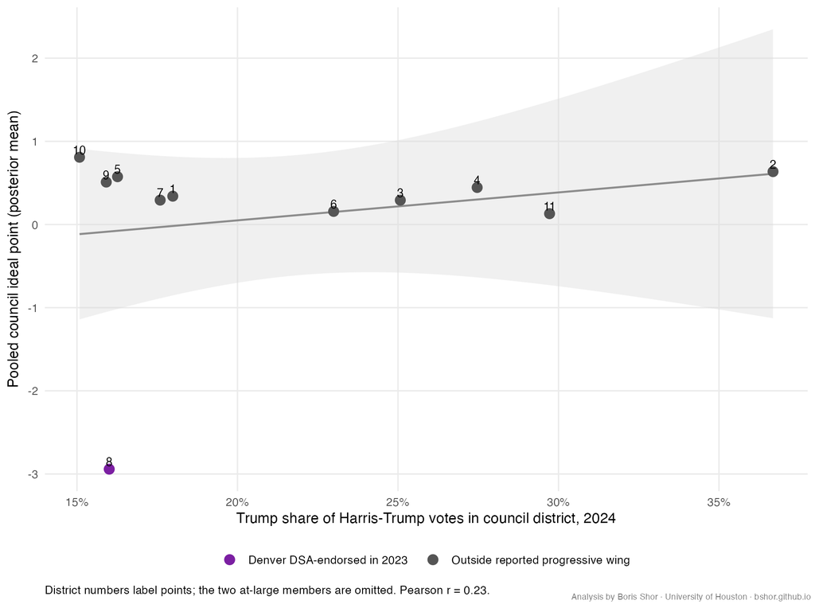

Council-district presidential voting and the pooled ideal point. Numbers identify districts; the two at-large members have no single district and are omitted.

The analysis assigns all 301 Denver precincts in the *New York Times* published 2024 presidential dataset to council districts using Denver’s official [2023 redistricting ordinance](https://denver.legistar.com/View.ashx?GUID=4C38F759-6D2E-48E3-9987-1A229367459D&ID=10655869&M=F). It then aggregates Harris and Trump votes and matches each district to its council member. The precinct data contain 278,634 Harris votes and 74,765 Trump votes. [*New York Times* precinct-data documentation](https://github.com/nytimes/presidential-precinct-map-2024)

The district relationship is positive but weak: Pearson’s correlation is **0.23** across eleven districts. In a simple bivariate regression, a ten-percentage-point increase in Trump’s two-party share corresponds to 0.34 ideal-point units, but the uncertainty is large (R² = 0.05; p = 0.49). The district presidential vote therefore does not provide the clear external ordering found in the Chicago pilot.

This is still informative. Denver council elections are [officially nonpartisan](https://www.axios.com/local/denver/2023/03/29/progressive-backed-candidates-denver-city-council), presidential vote varies within a heavily Democratic city, two of the most progressive members are elected at large and cannot enter the district comparison, and the council score pools a relatively small set of locally contested votes. Constituent presidential partisanship and council coalitions need not line up closely.

### Reported political groupings

The following labels are dated external classifications, not inferred from the roll calls. Axios identified Lewis, Parady, and Gonzales-Gutierrez as the council’s progressive wing in 2025 and again in 2026. Denver DSA endorsed Lewis and Parady in the 2023 council election. Denver does not have a directly comparable formal caucus system to the Chicago caucuses, so these are best read as face-validity checks on a small council rather than stable organizational memberships.

| Group | Members (N) | Median voting position |
| --- | --- | --- |
| Reported progressive wing | 3 | -1.07 |
| Outside reported progressive wing | 10 | 0.39 |

All three reported progressive-wing members appear at or below the center of the fitted scale, and the two DSA-endorsed members occupy its negative endpoint. The contrast is large and in the expected direction. Because it compares only three members with ten others—and because the grouping was itself recognized partly through public policy behavior—the result is corroborating description, not an independent test or a causal estimate.

## Interpretation and limits

Denver’s votes distinguish a progressive endpoint more clearly than they track district presidential voting. Repeated references to one Hinds block vote remain in the source pending an upstream correction. Detailed construction and estimation limits are in the technical appendix.